# Project 03: Chain Reaction

**First Draft Due:** Monday, December 4, 2023 at the start of class  
**Final Draft Due:** Thursday, December 7, 2023 at the end of the day  
**Name:** Camus Wang

You have been transported back in time (again!) this time to Enrico Fermi's office at the University of Chicago in 1942. Fermi is hard at work trying to build the first self-sustaining artificial nuclear reaction using Uranium 235. Once he calms down from the shock of witnessing time travel, Fermi has asked for your help to explore how factors such as size, shape and purity impact the ability of a sample of Uranium 235 to sustain a chain reaction.

Fermi initially presents you with his simplest model to help make it easy to troubleshoot and confirm the results from the Monte Carlo simulation that you will build of this chain reaction process. In this model, when a $^{235}U$ nucleus undergoes nuclear fission, it always releases two thermal neutrons, where a thermal neutron is one that is moving slowly enough to possibly be captured by other $^{235}U$ nuclei. These thermal neutrons will travel an average distance, known as the Mean Free Path $λ$, before being captured elsewhere in the sample. The probability of a thermal neutron being captured when it travels a distance $L$ is given by $p(L)∝e^{-L/λ}$. In this model, every captured thermal neutron results in an unstable $^{235}U$ nucleus which will almost immediately undergo its own fission process, releasing further neutrons, and possibly sustaining a chain reaction if enough of the neutrons are being captured inside the $^{235}U$ sample. You and Fermi have decided that a Monte Carlo process would be the best way to simulate this.

Your algorithm will look something like this:

1. Choose an initial number of thermal neutrons, $N$, to simulate.
2. Randomly generate $N$ starting locations within the Uranium for these initial thermal neutrons.
3. Randomly generate the directions of travel, in three dimensions, of the $N$ initial thermal neutrons.
4. Using the Mean Free Path, generate the distances, $L$, that the $N$ initial thermal neutrons will travel in the sample before being captured.
5. Determine how many of the neutrons are absorbed inside the sample after they have each traveled their randomly determined distance $L$ in their randomly determined direction from their randomly determined initial position. Neutrons that are still inside the sample after traveling their distance $L$ are considered to have been captured and will initiate a new fission event. Neutrons that do not remain inside the sample after traveling their distance $L$ are lost and will not initiate any further fission events.
6. Determine the number of new thermal neutrons generated, knowing that each of the new fission events will generate 2 new neutrons. We will call this total number of new thermal neutrons $N_{\text{new}}$.
7. Report the multiplication factor, $f=N_{\text{new}}/N$, for that simulation. If this value is above 1, the number of thermal neutrons being generated is increasing, which will result in a sustained nuclear chain reaction.

Some initial brainstorming with Fermi results in the starter code below to generate $N$ initial thermal neutrons inside a cube with sides of length $a$. You will first spend some time characterizing uncertainties in the system, developing an understanding of how choices such as the initial number of thermal neutrons $N$ and the number of trials $m_\text{trials}$ impacts these uncertainties. Then you will perform an investigation of how different parameters in the system, such as size, shape and purity, impact the system's ability to sustain a chain reaction (as determined by the multiplication factor).

```
def func(N):

    # N = Initial number of thermal neutrons

    # Length of the cube's side
    a = 0.50 # m

    # Fermi's best guess of the mean free path
    # based on the neutron cross section in U235
    mean_free_path = .15 # m

    # Generate a random initial decay position for each neutron
    x0 = a*(np.random.random(N)-.5)
    y0 = a*(np.random.random(N)-.5)
    z0 = a*(np.random.random(N)-.5)

    # Generate random initial directions for each neutron
    phi = 2*np.pi*(np.random.random(N))
    cos = 2*(np.random.random(N)-.5)
    theta =  np.arccos(cos)

    # Randomly generate the distance travelled
    d = -mean_free_path*np.log(np.random.random(N))

    # ... haven't finished the function yet
```

### Characterizing the system

An important part of the physical modelling process involves having a good understanding of the uncertainties in the system. Using the above starter code as an initial guide, build a system that characterizes the uncertainty in the Multiplication Factor for the following system:

- A cube with sides of length $a = 0.50 \text{ m}$,
- A mean free path of $\lambda = 0.15 \text{ m}$,
- Two new thermal neutrons generated per fission event, where every neutron that remains inside the sample will initiate a fission event
- $N_\text{thermal} = 1000$ initial thermal neutrons,
- Repeating the experimental $m_\text{trials} = 1000$ times to be able to charaterize the Multiplication Factor using mean and standard deviation.

It is not necessary that you generate a histogram like the one below, but we provide it to give you some initial guidance on the approximate results that you should expect to achieve with this initial characterization of uncertainty.

[figure not shown]

Once you are confident that your system is behaving as intended, do a quick investigation of the impact of $N_\text{thermal}$ and $m_\text{trials}$ on your uncertainty in the Multiplication Factor. Use these results, along with the actual time needed to run your simulation, to make informed decisions about what values of $N_\text{thermal}$ and $m_\text{trials}$ to use during your main investigation.

### Your investigation: Exploration of the Multiplication Factor

Fermi's main task for you is to explore how the Multiplication Factor varies as a function of the shape and size of the sample, its purity, and the use of neutron moderators. You should start by coming up with research question(s) that explore(s) the behavior of $f$ over the phase space of this system. You should then make a visualization that effectively shows your answer to that question. Your visualizations should include fits that quantitatively capture the relationship between $f$ and your parameter(s) of choice. If you choose to implement any physical extensions, it would be good for your visualizations to include some exploration or demonstration of what their effects are.

Some parameters that you could vary as well as places to extend the physics of the simulation:

- **Shapes and aspect ratios:** The shape of the sample, which could include fundamentally different shapes, such as spheres, cylinders, and rectangular prisms (boxes). A helpful way to characterize the relative dimensions of a given shape (other than spheres and cubes) is the Shape Aspect Ratio, $S$. For a rectangular prism with volume $a \times a \times b$, the Shape Aspect Ratio would be $S=a/b$. For a cylinder it would be $S=r/h$. Compare how different shapes and/or different Shape Aspect Ratios impact $f$.
- **Volume:** The volume of the sample, $V$.
- **Probability that captured neutrons initiate further fissions:** The purity of the Uranium, where the more pure the sample, the more likely it is that a thermal neutron stopping inside the sample will be captured by a $^{235}U$ nucleus and result in a subsequent fission. In Fermi's simplest model, we treated it as $p=1.0$ that a neutron stopping within the sample would cause a subsequent fission, but you can explore the impact of varying the purity of the sample via this parameter.
- **Mean free path:** Varying the mean free path in the sample via neutron moderators. When a thermal neutron interacts with a neutron moderator, it loses some kinetic energy, but has a negligible probability of actually being captured by the neutron moderator. In our simulation this can be modeled as reducing the mean free path of the neutrons in the sample since lower kinetic energies will mean that the neutrons travel less far before being absorbed.
- **Number of neutrons per fission:** Although we used two neutrons per fission in Fermi's simplest model, the average number of neutrons produced per $^{235}U$ fission is actually 2.4355.
- **Even more physics, coding and investigation extensions:** There is a lot of room to extend this project, which is a huge simplification of a nuclear chain reaction. One could account for the fact that more than one thermal neutron would have been generated at each location when generating our initial batch of thermal neutrons, could consider surrounding the sample with nuclear reflectors, could simulate multiple generations of fission events, could vary parameters such as $N_\text{thermal}$ and $m_\text{trials}$ in your phase space to do careful characterizations of uncertainty, and more.

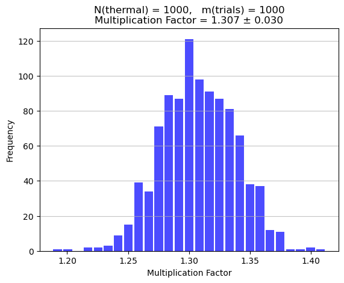

```python
import numpy as np
import matplotlib.pyplot as plt
from scipy.optimize import curve_fit

def is_inside_cube(x, y, z, a):
    # check if neutrons is inside the cube with side length a
    return  (np.abs(x) <= a/2) & (np.abs(y) <= a/2) \
            & (np.abs(z) <= a/2)

def func(N):

    # N = Initial number of thermal neutrons
    N = 1000

    # Length of the cube's side
    a = 0.50 # m

    # Fermi's best guess of the mean free path
    # based on the neutron cross section in U235
    mean_free_path = .15 # m

    # Probability that an absorbed neutron results in a fission
    p = 1.0

    # Generate a random initial decay position for each neutron
    x0 = a*(np.random.random(N)-.5)
    y0 = a*(np.random.random(N)-.5)
    z0 = a*(np.random.random(N)-.5)

    # Generate random initial directions for each neutron
    phi = 2*np.pi*(np.random.random(N))
    cos = 2*(np.random.random(N)-.5)
    theta =  np.arccos(cos)

    # Randomly generate the distance travelled
    d = -mean_free_path*np.log(np.random.random(N))

    # Calculate the final positions
    x = x0 + d*np.sin(theta)*np.cos(phi)
    y = y0 + d*np.sin(theta)*np.sin(phi)
    z = z0 + d*np.cos(theta)

    # Count neutrons absorbed inside the cube
    absorbed = np.sum(is_inside_cube(x, y, z, a))

    # Each absorbed
    N_fissions = sum(np.random.random(absorbed)<p)
    N_new = 2.* N_fissions # 2 new neutrons per fission event

    # Calculate the multiplication factor
    f = N_new/N
    return f

# Parameters
N_thermal = 1000
m_trials = 1000
multiplication_factors = []

# Run the simulation m_trials times
for _ in range(m_trials):
    multiplication_factors.append(func(N_thermal))

# Calculate the mean and standard deviation of the multiplication factors
mean_f = np.mean(multiplication_factors)
std_f = np.std(multiplication_factors)

def gen_histogram(multiplication_factors, mean_f, std_f):

    # Create the histogram
    plt.hist(multiplication_factors, bins='auto', color='blue', alpha=0.7, rwidth=0.85)
    plt.xlabel('Multiplication Factor')
    plt.ylabel('Frequency')
    plt.title(f"N(thermal) = 1000,   m(trials) = 1000\nMultiplication Factor = {mean_f:.3f} ± {std_f:.3f}")
    plt.grid(axis='y', alpha=0.75)
    #plt.savefig("f_histo.png")
    plt.show()

gen_histogram(multiplication_factors, mean_f, std_f)
```

# Background and Motivation

*(Provide some context for the problem and the specific reasearch question(s) you set out to answer. Make sure to discuss why your specific research question(s) would be interesting to investigate. Make sure to explicitly state which parameters you are changing and which paremeters you are keeping fixed. This is also the appropriate place to communicate your governing equations and introduce any additional equations that you might use to check the results of your code. Note: It is helpful for the graders if you are able to embed equations and calculations in the markdown or as images in the notebook instead of as additional files.)*

After our initial collaboration with Fermi to generate N initial thermal neutrons inside a cube with sides of length 'a,' we sought to deepen and guide our research further by adding many new considerations (parameters). The primary purpose of changing each parameter is to study its impact on the multiplication factor - whether it is constructive or destructive and how the degree of impact changes, followed by fitting the trend. Given the multitude of factors considered, our core idea revolves around controlling variables and analyzing them one by one. Below is an outline of the parameter changes:

A. Main Idea: Transforming a simple idealized model into a complex real-world model.

1. Considering the average number of neutrons produced per fission in reality. For instance, the actual fission of 235U produces an average of 2.4355 neutrons, so we will change from the ideal state of 2 to 2.4355 and maintain this parameter value.
2. Considering the impact of volume on the multiplication factor under the same other parameters. In this system, volume changes mainly occur in two ways: one is due to different sizes in the same shape (regular change), and the other is due to different shapes under the same size (irregular change). In this study, we discuss the impact of size variations ranging from 0-1m in three shapes: cube, sphere, and cylinder.
3. Considering the impact of the aspect ratio of the same shape on the multiplication factor. Models with varying aspect ratios mainly include the extension of the cube - the cylinder, and the extension of the sphere - the ellipse. In this study, we extract the cylinder and ellipse shapes to discuss the impact of aspect ratio changes on the multiplication factor.
4. Considering that there are still irregular shapes at the same volume, we compare simple regular shapes like the cube with irregular shapes of the same volume to discuss the impact of shape differences on the multiplication factor

# Methodology and computational code:

*(How did you go about answering your questions(s)? In 3-5 sentences, provide an overview of how your code below solves the problem. Additionally, include brief descriptions of any python packages you used beyond from the standard ones (i.e., those other than NumPy, Matplotlib or SciPy). You should also add citations for any of these in the references section.)*

The simulation effect of the above code is mainly used in the part of the function for calculating the multiplication factor, and a new parameter module is introduced. Pandas, visit https://pandas.pydata.org/pandas-docs/stable/.

*(Below is the part of your notebook that should include the majority of your code. Don’t put plots here, though, as they belong in the Data Vizualization section.)*

```python
# Your main code here
import numpy as np
import matplotlib.pyplot as plt
import pandas as pd
from scipy.optimize import curve_fit

"Since the meaning of each code has been explained in detail in the above study,"
"and the following studies are extensions of the above study,"
"the annotation of the code will be simplified by focusing on annotating the newly extended code."

def simulate_fission(N, a, mean_free_path, shape, aspect_ratio=1):
    # The newly added aspect_ratio represents the ratio of height to diameter
    # a means the size of sample(initial state)

    # Initialize Neutrons
    x0 = a*(np.random.random(N)-.5)
    y0 = a*(np.random.random(N)-.5)
    z0 = a*(np.random.random(N)-.5)
    phi = 2*np.pi*(np.random.random(N))
    cos = 2*(np.random.random(N)-.5)
    theta =  np.arccos(cos)
    d = -mean_free_path*np.log(np.random.random(N))

    # Calculate the final positions
    x = x0 + d*np.sin(theta)*np.cos(phi)
    y = y0 + d*np.sin(theta)*np.sin(phi)
    z = z0 + d*np.cos(theta)

    # Determining the shape of a sample
    if shape == "cube":
        inside = (np.abs(x) <= a/2) & (np.abs(y) <= a/2) \
                 & (np.abs(z) <= a/2)

    elif shape == "sphere":
        inside = (x**2 + y**2 + z**2) <= (a/2)**2

    elif shape == "cylinder": # Directed study 2
        inside = (x**2 + y**2 <= (a/2)**2) & (np.abs(z) <= a/2) # Assuming height is a

    elif shape == "cylinder2": # Directed study 3, 4
        # aspect_ratio =height/diameter
        initial_volume = np.pi * (a/2)**2*a
        # Initial volume, assuming initial height equals diameter
        new_radius = np.cbrt(initial_volume / (np.pi*aspect_ratio*2))
        new_height = 2*new_radius * aspect_ratio
        inside = (x**2 + y**2 <= (new_radius)**2) & (np.abs(z) <= new_height/2)

    elif shape == "ellipsoid":
        # We only change the radius in the z-axis and assume that it remains a circle in the xy-plane.
        # aspect_ratio =long_axis/short_axis
        initial_volume = (4/3)*np.pi*(a/2)**3
        # Initial volume, assuming initial long_axis equals radius
        new_radius = np.cbrt(initial_volume / ((4/3) * np.pi * aspect_ratio))
        long_radius = new_radius*aspect_ratio
        inside = ((x**2 + y**2) / (new_radius)**2 + z**2 / (long_radius)**2) <= 1

    else:
        raise ValueError("Invalid shape. Choose 'cube' or 'sphere' or 'cylinder' or 'cylinder2' or 'ellipsoid'.")

    # Count neutrons absorbed inside the simple
    absorbed = np.sum(inside)

    # Probability that an absorbed neutron results in a fission
    p = 1.0
    N_fissions = sum(np.random.random(absorbed)<p)

    # Average number of thermal neutrons
    N_therm_ave = 2.4355
    N_new = N_therm_ave * N_fissions
    f = N_new/N
    return f

# simultaneous equations
def model(x, a, b, c):
    return a * np.log(b * x + c)
```

```python
# Add additional cells as needed, but your main visualizations should be produced in the section below
def plot_Multiplication_Factor_volume(sample_sizes, shapes, N, mean_free_path, m_trials):
    results = []

    for shape in shapes:
        for size in sample_sizes:
            multiplication_factors = [] # Initialize here
            for _ in range(m_trials):
                multiplication_factors.append(simulate_fission(N, size, mean_free_path, shape, aspect_ratio=1))
            mean_f = np.mean(multiplication_factors)
            std_f = np.std(multiplication_factors)
            results.append({"Shape": shape, "Size": size, "Multiplication Factor": mean_f, "Error": std_f})

    results_df = pd.DataFrame(results)

    # Plotting
    fig, ax = plt.subplots()
    for shape in shapes:
        subset = results_df[results_df["Shape"] == shape]
        ax.errorbar(subset["Size"], subset["Multiplication Factor"] \
                        , yerr=subset["Error"], fmt = "o", capsize=5, label=f"Shape:{shape}")

        # Fitting the function
        yerror = subset["Error"]
        popt, _ = curve_fit(model, subset["Size"], subset["Multiplication Factor"], sigma=yerror, \
                            absolute_sigma=True)
        ax.plot(subset["Size"], model(subset["Size"], *popt), label=f"Fit: {shape}")

    ax.axhline(1, color="grey", linestyle="--")
    ax.set_xlabel("Sample Size (m)")
    ax.set_ylabel("Average Multiplication Factor")
    ax.set_title("Multiplication Factor vs Sample Size for Different Shapes")
    ax.legend()
    plt.show()
```

```python
def plot_multiplication_factor_aspect_ratio(sample_sizes, shapes, N, mean_free_path, m_trials, aspect_ratios):
    results = []

    # New here is a consideration of different aspect ratios
    for shape in shapes:
        for aspect_ratio in aspect_ratios:
            for size in sample_sizes:
                multiplication_factors = []
                for _ in range(m_trials):
                    multiplication_factors.append(simulate_fission(N, size, mean_free_path, shape, aspect_ratio))
                mean_f = np.mean(multiplication_factors)
                std_f = np.std(multiplication_factors)
                results.append({"Shape": shape, "Aspect Ratio": aspect_ratio, "Size": size, "Multiplication Factor": mean_f, "Error": std_f})

    results_df = pd.DataFrame(results)

     # Plotting
    fig, axs = plt.subplots(len(shapes), len(aspect_ratios), figsize=(8,8))
    for i, shape in enumerate(shapes):
        for j, aspect_ratio in enumerate(aspect_ratios):
            subset = results_df[(results_df["Shape"] == shape) & \
                               (results_df["Aspect Ratio"] == aspect_ratio)]
            axs[i, j].errorbar(subset["Size"], subset["Multiplication Factor"], yerr=subset["Error"], fmt="o", capsize=5)
            axs[i, j].set_title(f"R: {aspect_ratio:.2f}")
            axs[i, j].axhline(1, color="grey", linestyle="--")
            if i == len(shapes) - 1:
                axs[i, j].set_xlabel("Sample Size (m)")
            if j == 0:
                axs[i, j].set_ylabel(f"Average Multiplication Factor of {shape}")

            # Fitting the function
            yerror = subset["Error"]
            popt, _ = curve_fit(model, subset["Size"], subset["Multiplication Factor"], sigma=yerror, \
                                absolute_sigma=True)
            axs[i, j].plot(subset["Size"], model(subset["Size"], *popt))

    plt.suptitle("Multiplication Factor vs Sample Size for Different Shapes and Aspect Ratios(R)")
    plt.tight_layout()
    plt.show()
```

# Error testing

*(Convince yourself that your system, from a physics and a coding perspective, is behaving correctly and provide your most compelling evidence here. This may include calculations, notes, common-sense checking of the input and output from your code, or running the code with specific parameters to make sure everything behaves how you expect. It may also include visualizations whose purpose is strictly related to error checking. Use as many code and markdown cells as you need. Note: It is helpful for the graders if you are able to embed equations and calculations in the markdown or as images in the notebook instead of as additional files.)*

First I want to check if the volume is constant in the cylinder2 and ellipsoid sections

For cylinder: volume=$\pi r^2h$ and R(aspect-ratio)=$\frac{h}{2r}$.

For ellipsoid: volume=$\frac{4}{3}\pi abc$(abc are the three axes) and R(aspect-ratio)=$\frac{long-axis}{short-axis}$.

```python
# Your error checking code, function calls and plotting code. Add more code cells as needed.
a = 0.5
aspect_ratio = 1

initial_volume_cylinder = np.pi * (a/2)**2 * a
new_radius_cylinder = np.cbrt(initial_volume_cylinder / (np.pi * aspect_ratio * 2))
new_volume_cylinder = np.pi * new_radius_cylinder**2 * (2 * new_radius_cylinder * aspect_ratio)
assert np.isclose(initial_volume_cylinder, new_volume_cylinder), "Cylinder volume changed"

initial_volume_ellipsoid = (4/3) * np.pi * (a/2)**3
new_radius_ellipsoid = np.cbrt(initial_volume_ellipsoid / ((4/3) * np.pi * aspect_ratio))
new_volume_ellipsoid = (4/3) * np.pi * new_radius_ellipsoid**2 * ( new_radius_ellipsoid * aspect_ratio)
assert np.isclose(initial_volume_ellipsoid, new_volume_ellipsoid), "Ellipsoid volume changed"
```

```python
a = 0.5
aspect_ratio = 1.6

initial_volume_cylinder = np.pi * (a/2)**2 * a
new_radius_cylinder = np.cbrt(initial_volume_cylinder / (np.pi * aspect_ratio * 2))
new_volume_cylinder = np.pi * new_radius_cylinder**2 * (2 * new_radius_cylinder * aspect_ratio)
assert np.isclose(initial_volume_cylinder, new_volume_cylinder), "Cylinder volume changed"

initial_volume_ellipsoid = (4/3) * np.pi * (a/2)**3
new_radius_ellipsoid = np.cbrt(initial_volume_ellipsoid / ((4/3) * np.pi * aspect_ratio))
new_volume_ellipsoid = (4/3) * np.pi * new_radius_ellipsoid**2 * ( new_radius_ellipsoid * aspect_ratio)
assert np.isclose(initial_volume_ellipsoid, new_volume_ellipsoid), "Ellipsoid volume changed"
```

```python
a = 2
aspect_ratio = 1

initial_volume_cylinder = np.pi * (a/2)**2 * a
new_radius_cylinder = np.cbrt(initial_volume_cylinder / (np.pi * aspect_ratio * 2))
new_volume_cylinder = np.pi * new_radius_cylinder**2 * (2 * new_radius_cylinder * aspect_ratio)
assert np.isclose(initial_volume_cylinder, new_volume_cylinder), "Cylinder volume changed"

initial_volume_ellipsoid = (4/3) * np.pi * (a/2)**3
new_radius_ellipsoid = np.cbrt(initial_volume_ellipsoid / ((4/3) * np.pi * aspect_ratio))
new_volume_ellipsoid = (4/3) * np.pi * new_radius_ellipsoid**2 * ( new_radius_ellipsoid * aspect_ratio)
assert np.isclose(initial_volume_ellipsoid, new_volume_ellipsoid), "Ellipsoid volume changed"
```

I checked whether the volume of the cylinder and ellipsoid changed with it, using two different initial conditions and the same calculation of the volume as in the code, and the results of both passed the test, so it proves that the code part is correct for the calculation of the new radius and the new height and the new long axis

```python
# Assumed test parameters
N = 1000
mean_free_path = 0.2
sample_size = 1.5
shapes = ["cube", "sphere", "cylinder", "ellipsoid"]
absorbed_counts = {}
N_therm_ave = 2.4355

for shape in shapes:
    absorbed_counts[shape]= simulate_fission(N, sample_size,\
                                             mean_free_path, shape, aspect_ratio=1)

for shape, count in absorbed_counts.items():
    print(f"shape: {shape}, absorbed neutrons: {count*N/N_therm_ave:.1f}")
```

```
shape: cube, absorbed neutrons: 815.0
shape: sphere, absorbed neutrons: 471.0
shape: cylinder, absorbed neutrons: 676.0
shape: ellipsoid, absorbed neutrons: 503.0
```

```python
N = 10000
mean_free_path = 0.2
sample_size = 1.5
shapes = ["cube", "sphere", "cylinder", "ellipsoid"]
absorbed_counts = {}
N_therm_ave = 2.4355

for shape in shapes:
    absorbed_counts[shape]= simulate_fission(N, sample_size,\
                                             mean_free_path, shape, aspect_ratio=1)

for shape, count in absorbed_counts.items():
    print(f"shape: {shape}, absorbed neutrons: {count*N/N_therm_ave:.1f}")
```

```
shape: cube, absorbed neutrons: 8245.0
shape: sphere, absorbed neutrons: 4768.0
shape: cylinder, absorbed neutrons: 6893.0
shape: ellipsoid, absorbed neutrons: 4824.0
```

```python
N = 1000
mean_free_path = 0.5
sample_size = 1.5
shapes = ["cube", "sphere", "cylinder", "ellipsoid"]
absorbed_counts = {}
N_therm_ave = 2.4355

for shape in shapes:
    absorbed_counts[shape]= simulate_fission(N, sample_size,\
                                             mean_free_path, shape, aspect_ratio=1)

for shape, count in absorbed_counts.items():
    print(f"shape: {shape}, absorbed neutrons: {count*N/N_therm_ave:.1f}")
```

```
shape: cube, absorbed neutrons: 619.0
shape: sphere, absorbed neutrons: 363.0
shape: cylinder, absorbed neutrons: 526.0
shape: ellipsoid, absorbed neutrons: 370.0
```

Three different initial values were detected, logically increasing the N value absorbs more neutrons, increasing the average distance traveled absorbs fewer neutrons, and the number of neutrons absorbed changes with repetition of the experiment, and the four shapes should be ordered according to the number of neutrons absorbed from the largest to the smallest volume. The above several logical judgments are passed, we have reason to believe that the simulation of the decay system is correct

# Data visualization, interpretation and presentation of results

*(This section should include code that produces your visualizations and any other aspects of your data or results that you would like to present. Make sure to provide caption-style summaries with everything presented in this section so that the reader can understand and correctly interpret your visualizations and presented results.)*

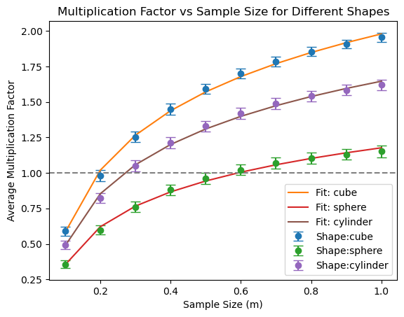

```python
# Plotting and other code that presents results. Add more code cells as needed.
sample_sizes = np.linspace(0.1, 1.0, 10)
shapes1 = ["cube", "sphere", "cylinder"] # Extract the model we need to consider
m_trials = 1000
N = 1000
mean_free_path = 0.15

plot_Multiplication_Factor_volume(sample_sizes, shapes1, N, mean_free_path, m_trials)
```

The graph presents the results under the second aspect of our main idea: the impact of volume variation on the multiplication factor. Initially, we maintained certain parameters constant: 1,000 initial neutrons, 1,000 repetitions of the experiment, and an average mean free path of 0.15 meters. The variables considered were three different shapes - cube, sphere, and cylinder. For the sphere and cylinder, we assumed they were inscribed within a cube, leading to the cube having the largest volume, followed by the cylinder and then the sphere. The sizes ranged from 0 meters to 1 meter.

Regarding the fitting function, after plotting the primary data points, a linear model was initially used for approximation. However, it was observed that the data tended to flatten out along the x-axis, indicating a logarithmic growth pattern. Without initial guesses, the fitting results adequately met our requirements, thus completing the test.

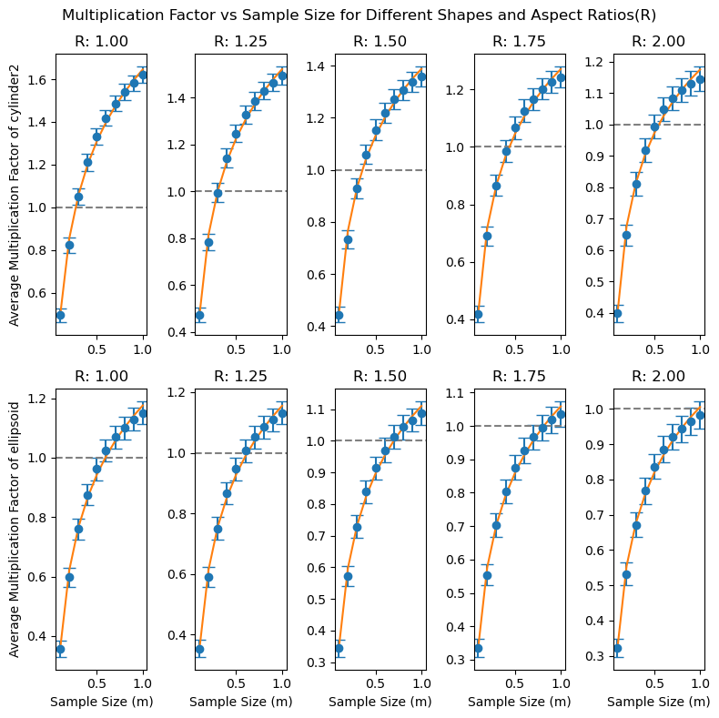

```python
sample_sizes = np.linspace(0.1, 1.0, 10)
shapes2 = ["cylinder2", "ellipsoid"] # Extract the model we need to consider
m_trials = 1000
N = 1000
mean_free_path = 0.15
aspect_ratios = np.linspace(1, 2, 5) # Five aspect ratios from 1 to 2

plot_multiplication_factor_aspect_ratio(sample_sizes, shapes2, N, \
                                         mean_free_path, m_trials, aspect_ratios)

# Note!!!
# the shape annotations are on the y-axis, this is to make the image aesthetically pleasing
# The x-axis at this point represents the same volume, and since the aspect ratio has changed,
# the SIZE is just the radius and height in the initial state. (R=1)
```

The graph represents the third and fourth aspects of our main theme: the impact of shape aspect ratios and different shapes on the multiplication factor. Initially, we maintained certain parameters constant: 1,000 initial neutrons, 1,000 repetitions of the experiment, and an average mean free path of 0.15 meters. The variables considered were the aspect ratios of shapes, specifically two shapes: cylinders and ellipsoids. For the cylinder, the initial state assumes the height equals the diameter, while for the ellipsoid, all three axes are of equal length. I modified the height of the cylinder and the long axis of the ellipsoid along the z-axis using the aspect ratio and employed the area formulas of the cylinder and ellipsoid to ensure the volume remains constant after changing the aspect ratio.

# Synthesis and discussion

Research objectives Our study aims to investigate how three key aspects of nuclear physics simulations: volume and shape and aspect ratio affect multiplication factors.

Experimental Setup The study was carried out under consistent conditions: 1,000 initial neutrons, 1,000 experimental repetitions, and an average mean free path of 0.15 m. Here we also update the actual value of the decay, n = 2.4355. We focus on the multiplication factor performance of different shapes-cubes, cylinders, spheres (with decreasing volumes in that order)-and two shapes-ellipsoids, with cylinders varying their volumes and aspect ratios when the multiplication factor behaves.

Limitations and future directions Physical modeling: Our model is based on idealized shape conditions and may not fully represent the complexity of real-world nuclear materials. Computational limitations: The accuracy of the simulations depends on the computational resources and algorithms, which may limit the detailed exploration of certain situations, such as irregular objects. Parameter selection: The selected parameters, while consistent, may not cover the full range of real-world nuclear physics scenarios. For future work, we recommend

Investigate a wider range of shapes to better model real-world conditions. Incorporate more realistic physical conditions such as temperature and material composition. Utilize advanced computational models to improve simulation accuracy. Conclusion. This study provides important insights into the effects of volume and shape and aspect ratio on multiplication factors.